# Detecting a Gerrymander Without a Map

Three bias statistics on one column of numbers, and the states where they disagree

Democracy’s Data

Last updated September 13, 2026 at 10:53a EDT

Here is North Carolina’s congressional delegation in 2024, written out as a row of numbers. Each one is the Democratic share of the two-party presidential vote inside a district, sorted from most Democratic to least:

> 73.5 73.0 67.5 48.4 45.2 43.0 42.4 42.0 41.5 41.4 41.0 41.0 40.1 39.0

3 districts up in the high sixties and seventies, 11 down in the high thirties and forties, and nothing whatever in the middle, in a state that was 48.5% Democratic overall.

No map was consulted to produce that row, and none is needed to see that something has been done to it. That is fortunate, because shape is a poor guide to districting. Gerrymandered districts are often perfectly tidy, and some of the ugliest districts in America are ugly because a river is. So the question worth asking is whether you can catch a gerrymander from the numbers alone.

The answer decides what an ordinary voter can do about one. A claim resting on a public table is a claim anybody can check for their own state. A claim resting on a mapmaker’s testimony is not.

## The test

Using the 2024 presidential vote counted inside every congressional district, compiled from precinct returns by the researcher Jay Timm and downloadable at https://github.com/jaytimm/PresElectionResults.

Presidential results rather than House results, and that choice is the method. To ask whether a *map* is biased you have to hold the voters still and vary only the lines. House results cannot do that, because they mix the map together with incumbency, money, scandal and seats nobody contested. The presidential race is the same contest in all 434 districts here, so any difference in how those votes become seats belongs to the plan. This is how the question is asked in litigation.

No agency publishes this table. States canvass by county and by precinct, because that is how ballots are counted. Congressional districts are drawn across those units by a different body for a different purpose, and nobody is obliged to reconcile the two. So a private individual assembles it and posts it in a public repository, which is a pleasant change from most of the sources in this book and also means there is no version of record.

**The join underneath the file is the step you cannot audit.** Precincts do not nest inside congressional districts. Where a district line cuts a precinct, somebody decides how that precinct’s votes divide, usually by assuming something about where inside the precinct the voters live. The file arrives with the decision made and no column recording it. Join Keys and Crosswalks is the chapter on matches of that kind, and on the crosswalk, a table that translates one set of areas into another, that a careful version needs. Two analysts using land area and population would produce different numbers in this file, and nothing in it would look any different.

## The data

One row is one congressional district, carrying the 2024 presidential vote counted inside it. The columns are `state`, `cd` and `district`, then `democrat` and `republican` as percentages, `pres_party` for who carried it, and `house_rep` with `house_rep_party` for who represents it.

| District | Harris % | Trump % | Democratic % of the two-party vote | Presidential winner | Party of the member elected |
| --- | --- | --- | --- | --- | --- |
| ME-02 | 44.22 | 53.75 | 45.14 | republican | NA |
| NC-01 | 47.97 | 51.06 | 48.44 | republican | democrat |

`dem_share` is the only column added here: `democrat` divided by the two of them together. It is the Democratic share of the *two-party* vote, and it discards third-party and write-in ballots so that fifty per cent means tied. That bottom number is a choice, and everything below rests on it.

Two cleaning decisions are worth the space. Maine runs ranked-choice House elections, and the compilation records ME-02’s winner as “Continuing Ballots” with an empty string where the party goes. An empty string is not a missing value, and the software will not warn you about the difference. Grouped by party, that row quietly becomes its own party. The row is kept, because its presidential figures are sound, and the party is set to genuinely missing instead.

New York’s twenty-first carries no presidential figures at all. It is dropped rather than filled in with a state average, so every national count below is over 434 districts and not 435.

> **Before you read on, make a prediction.** North Carolina and Wisconsin will sit at the Republican-favoring end of every statistic below. Write down which states you expect at the *other* end, and what you would conclude about the people who drew those maps.

## What it says about democracy

Three statistics are computed here, each from `dem_share` alone, for every state with six districts or more. All three are oriented the same way: a negative number means the plan favors Republicans.

The **efficiency gap** counts **wasted votes**: every vote cast for a losing candidate, and every vote for a winner beyond the half needed to win. The party that wastes far fewer of its votes is the one the lines serve. When every district has the same turnout, the count collapses to a formula on shares alone, the Democratic seat share above one-half minus twice the Democratic vote share above one-half, and that is the version computed here.[^1] The **mean minus median** subtracts the average district’s Democratic share from the median district’s, the one in the middle when the districts are sorted.[^2] When the median district is more Republican than the average one, half the seats are gone before the average voter is reached. The **declination** measures the kink where the sorted shares cross fifty. It compares how deeply a party wins the seats it wins against how narrowly it loses the ones it loses, which is the packing-and-cracking signature stated as an angle.[^3]

To win most of the seats with fewer than half the votes you do two things. **Pack** the other side into a few districts they carry overwhelmingly, wasting their surplus. **Crack** the rest across many districts where they lose narrowly, wasting all of it. Both moves leave the same mark: an empty band around the majority line.

North Carolina makes the wasted-vote arithmetic concrete. Give every district a hundred votes, so that shares are counts. In NC-04, which Harris carried with 73.0% of the two-party vote, Democrats wasted 23.0 votes, the surplus past fifty, and Republicans wasted all 27.0 of theirs. In NC-13, which she lost with 41.5%, Democrats wasted all 41.5 of their votes and Republicans only the 8.5 beyond what they needed. Add up the 14 districts and Democrats wasted 529.1 votes to the Republicans’ 170.9. Republicans wasted 358.2 fewer, which spread over 14 districts of a hundred votes each comes to -25.6: the same figure the formula returns, with the minus sign carrying the convention that a negative gap favors Republicans.

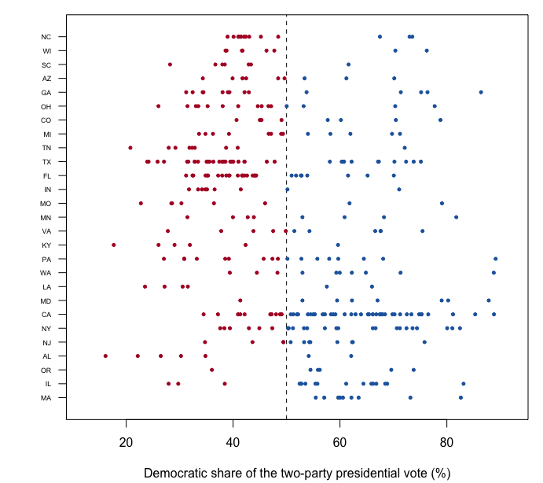

**Figure 1. Every state’s districts on one axis, ordered by efficiency gap.** A strip of dots per state, because the finding is a shape rather than a number. Where a plan has been packed and cracked, the dots pull away from the dashed majority line and leave a hole. North Carolina’s is -25.6 on the efficiency gap and Wisconsin’s -25.4, the two most Republican-favoring plans in the country, and both rows have that hole in them.

Seven states carry most of the argument that follows. Here they are with all three statistics side by side.

| State | Districts | Democratic vote % | Democratic seats | Efficiency gap | Mean minus median | Declination |
| --- | --- | --- | --- | --- | --- | --- |
| NC | 14 | 48.5 | 3 | -25.6 | -6.3 | -0.58 |
| WI | 8 | 50.2 | 2 | -25.4 | -6.2 | -0.56 |
| TN | 9 | 36.3 | 1 | -11.5 | -3.9 | -0.60 |
| GA | 14 | 49.8 | 5 | -13.9 | -9.1 | -0.33 |
| LA | 6 | 39.4 | 2 | 4.5 | -8.3 | -0.02 |
| MA | 9 | 63.8 | 9 | 22.4 | -3.3 | undefined |
| PA | 17 | 49.4 | 8 | -1.7 | -1.0 | -0.03 |

**The three statistics mostly agree, and where they part company they are informative.** Across the states scored here, the efficiency gap and the declination rank the plans nearly alike, at a rank correlation of 0.89, a score of how alike two orderings are on which 1 means identical. The mean minus median ranks them quite differently, at 0.31. Three measurements of one idea, disagreeing that much, is a warning against quoting any of them alone.

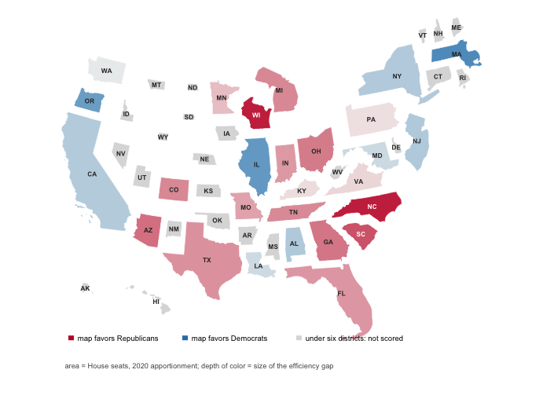

That last point is the objection the whole field turns on. **Massachusetts scores 22.4, nearly as extreme as North Carolina in the opposite direction, and it is not gerrymandered.** The state is 63.8% Democratic and elects Democrats in all 9 of its seats, because there is no way to carve a Republican district out of Massachusetts without deliberately trying to. Chen and Rodden (2013) formalized this: Democratic voters concentrate in cities at very high densities and waste enormous numbers of votes before anybody picks up a pen.[^4]

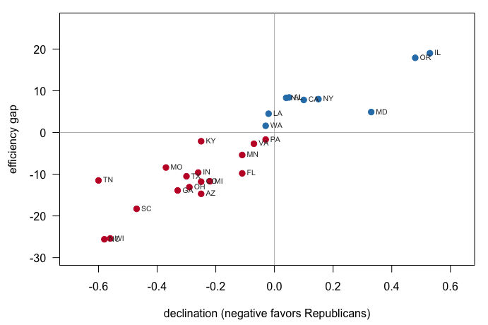

**Figure 3. Two of the statistics against each other.** One point per state, placed by its declination and its efficiency gap. One state is missing, MA, and its absence is the finding. With no district below fifty there is no Democratic loss to set against a Democratic win, so the declination cannot be computed there. The statistic that flags North Carolina cannot flag Massachusetts, because in Massachusetts there is nothing of that kind to flag.

The correction cuts the other way too. **Louisiana** scores 4.5 on the efficiency gap, which points at a Democratic advantage, and -8.3 on the mean minus median, which points the opposite way. Its 2024 map contains a second majority-Black district drawn under court order,[^5] and that produces a lopsided distribution for a reason with nothing to do with partisan advantage. Two statistics, disagreeing, for a reason that can be named. That is the honest state of this field.

## What this brief cannot tell you

**Every number here measures bias, and none of them measures intent.** Intent is what courts litigate, and it is proved from drafts, memoranda and email rather than from statistics. Sliding from “the efficiency gap is -25.6” to “they cheated” skips the only step that would matter in a courtroom. The numbers can tell you which maps are worth a subpoena. They cannot tell you what the subpoena will find.

**No single map’s numbers can separate drawn bias from geographic bias.** The method that can is simulation: generate thousands of legal maps and ask where the enacted plan falls among them. That argument has persuaded state courts,[^6] and it needs precinct geography this table does not carry.

Three narrower limits. The efficiency gap computed here is an approximation, because the proper version needs turnout by district and this file has shares rather than counts. Everything rests on one election, and a plan that looks fair against 2024 may not against 2020. And there are no dates in the file, so several plans drawn or redrawn by courts are not marked as such.

## What you should have learned

- A plan can be identified as biased from a printed row of vote shares, with no map consulted: 3 of North Carolina’s 14 districts sit above fifty per cent and nothing sits near it.
- Three statistics computed from the same column rank the states differently. The efficiency gap and the declination agree at a rank correlation of 0.89; the mean minus median agrees with the efficiency gap at only 0.31.
- Each disagreement names something real. Tennessee’s declination of -0.60 catches a cracked city that its efficiency gap of -11.5 misses, and Louisiana’s two statistics point in opposite directions because of a court-ordered district.
- A large statistic is not proof of a gerrymander. Massachusetts scores 22.4 because its Democratic voters are too numerous and too concentrated for a Republican district to exist, and its declination cannot even be computed.
- Bias is measurable and intent is not, which is why these numbers begin a case rather than finishing one.

## Extensions

None of these is answered above, and every one can be answered from the table the Sources section hands over.

- `pres_by_cd_2024.csv` has `dem_share` and `house_rep_party`. Count the districts where the presidential winner’s party and the member’s party disagree. Is that a gerrymander, or a good candidate?
- Sort `pres_by_cd_2024.csv` by `dem_share` and look at the whole distribution. Are the districts bunched near the middle or piled at the ends, and does the answer change if you do it one `state` at a time?
- Group `pres_by_cd_2024.csv` by `state` and take the largest `dem_share` below fifty and the smallest above it. That distance is the hole this brief keeps pointing at. Which states have the widest, and do they match Figure 1?
- `democrat` and `republican` do not sum to 100 in `pres_by_cd_2024.csv`. Work out the third-party share district by district, and find where discarding it moves `dem_share` most.
- **Stretch.** Find a compilation of the 2020 presidential vote by district and repeat one state’s statistics on it. Does the plan look the same against a different election?
- **Stretch.** Pick one state with a large gap and read its enacted map’s litigation record. Does the documentary evidence say what the numbers suggested?

## Sources

**Data**

- Presidential results by congressional district, 2024, compiled by the researcher Jay Timm and published as `PresElectionResults` (https://github.com/jaytimm/PresElectionResults); 434 of 435 districts, with the missing one documented rather than filled in. The compilation rests on precinct returns apportioned into district lines, and records nothing about how the split precincts were divided.

**The data itself**

Every figure above is drawn from these tables. They are plain CSV, they open in a spreadsheet, and they are yours to take further.

`deviation.csv`, `deviation_states.csv`, `pres_by_cd_2024.csv`, `seat_rings.csv`, `seat_states.csv`

**Academic literature**

- Bernstein, M. and Duchin, M. (2017). “A Formula Goes to Court: Partisan Gerrymandering and the Efficiency Gap.” *Notices of the American Mathematical Society* 64(9): 1020–1024. https://www.ams.org/journals/notices/201709/rnoti-p1020.pdf
- Chen, J. and Rodden, J. (2013). “Unintentional Gerrymandering: Political Geography and Electoral Bias in Legislatures.” *Quarterly Journal of Political Science* 8(3): 239–269. doi:10.1561/100.00012033; the authors’ copy is at https://web.stanford.edu/~jrodden/wp/florida.pdf
- McDonald, M. D. and Best, R. E. (2015). “Unfair Partisan Gerrymanders in Politics and Law: A Diagnostic Applied to Six Cases.” *Election Law Journal* 14(4): 312–330. The mean-median test. doi:10.1089/elj.2015.0358
- McGhee, E. (2014). “Measuring Partisan Bias in Single-Member District Electoral Systems.” *Legislative Studies Quarterly* 39(1): 55–85. doi:10.1111/lsq.12033
- Stephanopoulos, N. O. and McGhee, E. M. (2015). “Partisan Gerrymandering and the Efficiency Gap.” *University of Chicago Law Review* 82(2): 831–900. https://chicagounbound.uchicago.edu/uclrev/vol82/iss2/4/
- Warrington, G. S. (2018). “Quantifying Gerrymandering Using the Vote Distribution.” *Election Law Journal* 17(1): 39–57. The declination, as computed here. Preprint: https://arxiv.org/abs/1705.09393

**Cases**

- *Thornburg v. Gingles*, 478 U.S. 30 (1986). https://www.law.cornell.edu/supremecourt/text/478/30
- *Allen v. Milligan*, 599 U.S. 1 (2023), behind the court-ordered districts in Alabama and Louisiana. https://www.law.cornell.edu/supremecourt/text/21-1086
- *League of Women Voters of Pennsylvania v. Commonwealth*, 178 A.3d 737 (Pa. 2018) — the state constitutional route that replaced Pennsylvania’s 2011 plan with the one measured here. Case file at the Brennan Center: https://www.brennancenter.org/our-work/court-cases/league-women-voters-pennsylvania-v-commonwealth-pennsylvania
- *Gill v. Whitford*, 585 U.S. 48 (2018), https://www.law.cornell.edu/supremecourt/text/16-1161, and *Rucho v. Common Cause*, 588 U.S. 684 (2019), https://www.law.cornell.edu/supremecourt/text/18-422, which closed the federal courts to partisan gerrymandering claims and left state constitutions as the venue.
- *Louisiana v. Callais*, 608 U.S. ___ (2026), decided 29 April 2026, narrowing what Section 2 of the Voting Rights Act requires. Several of the packed districts visible in this file exist partly because of the older reading. https://www.supremecourt.gov/opinions/25pdf/24-109_21o3.pdf

Rebuild this data yourself, with an AI assistant

```
I want to rebuild a public dataset from its original source, without
any starting files. Please do the following and show your work.

THE SOURCE. Jason Timm's "PresElectionResults", a compilation of
presidential results by congressional district, on GitHub. One R data
file:
https://raw.githubusercontent.com/jaytimm/PresElectionResults/master/data/pres_by_cd.rda
No account or key is needed. Load it in R with load(); each row is
one of the 435 congressional districts, carrying the Democratic and
Republican shares of the 2024 presidential vote there and the name
and party of the House member the district elected.

WHAT TO BUILD.
1. The two-party Democratic share of the 2024 presidential vote in
   every district, next to which party won the district's House
   seat. One district carries no presidential figures at all —
   report which, then drop it. Maine's second district reports its
   House winner in a way that carries no party; keep the row and
   leave the party blank rather than guessing.
2. From that table: how many districts the Democratic ticket
   carried, how many sit in the competitive 45-55% band, and how
   many voted one way for president and the other way for the House.

CHECK YOUR WORK. The copy this book used was downloaded in August 2026.
If your rebuild matches it, you should find:
- 435 districts in the file, 434 kept after the drop
- every kept district's Democratic share strictly between 0 and 100
The compilation is maintained by its author and will change when
states redraw their maps; different districts then mean a different
map, not an error.
```

[^1]: Nicholas O. Stephanopoulos and Eric M. McGhee, “Partisan Gerrymandering and the Efficiency Gap,” *University of Chicago Law Review* 82, no. 2 (2015): 831–900, https://chicagounbound.uchicago.edu/uclrev/vol82/iss2/4/.
[^2]: Michael D. McDonald and Robin E. Best, “Unfair Partisan Gerrymanders in Politics and Law: A Diagnostic Applied to Six Cases,” *Election Law Journal* 14, no. 4 (2015): 312–330, doi:10.1089/elj.2015.0358.
[^3]: Gregory S. Warrington, “Quantifying Gerrymandering Using the Vote Distribution,” *Election Law Journal* 17, no. 1 (2018): 39–57; the preprint is at https://arxiv.org/abs/1705.09393.
[^4]: Jowei Chen and Jonathan Rodden, “Unintentional Gerrymandering: Political Geography and Electoral Bias in Legislatures,” *Quarterly Journal of Political Science* 8, no. 3 (2013): 239–269, https://web.stanford.edu/~jrodden/wp/florida.pdf.
[^5]: Drawn in January 2024 after the federal courts found the prior map likely to violate Section 2 of the Voting Rights Act, following *Allen v. Milligan*, 599 U.S. 1 (2023), https://www.law.cornell.edu/supremecourt/text/21-1086. The Supreme Court later held the district an unconstitutional racial gerrymander in *Louisiana v. Callais* (2026), https://www.supremecourt.gov/opinions/25pdf/24-109_21o3.pdf, after these votes were cast.
[^6]: Pennsylvania’s supreme court struck the state’s 2011 congressional map on evidence of that kind in *League of Women Voters of Pennsylvania v. Commonwealth*, 178 A.3d 737 (Pa. 2018); the case file is summarised by the Brennan Center: https://www.brennancenter.org/our-work/court-cases/league-women-voters-pennsylvania-v-commonwealth-pennsylvania.